# Презентация по лабораторной работе №8

Дисциплина: операционные системы

Лобанова П. И.

Российский университет дружбы народов, Москва, Россия

01.04.2023

# Информация

## Докладчик

- Лобанова Полина Иннокентьевна
- учащаяся факультета физико-математических и естественных наук
- учащаяся направления “Математика и механика”
- Российский университет дружбы народов
- polla-2004@mail.ru

# Цель работы

Познакомиться с операционной системой Linux. Получить практические навыки работы с редактором vi, установленным по умолчанию практически во всех дистрибутивах.

# Ход работы

## Редактор vi

В большинстве дистрибутивов Linux в качестве текстового редактора по умолчанию устанавливается интерактивный редактор vi (Visual display editor). Он имеет три режима работы: командный режим, режим вставки и режим последней строки.

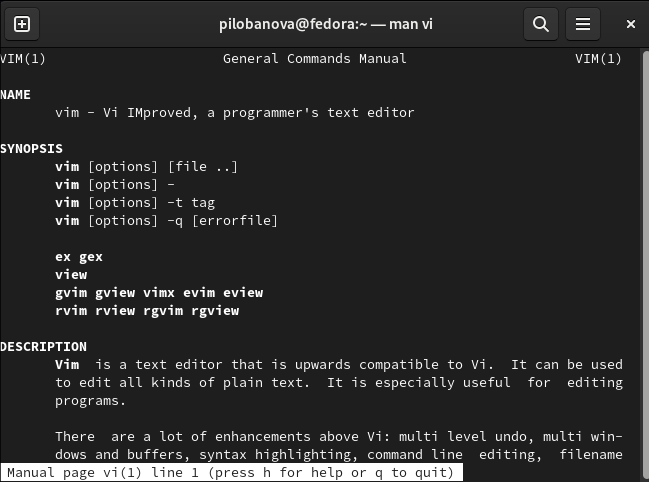

*Информация о редакторе vi.*

## Командный режим

Командный режим предназначен для ввода команд редактирования и навигации по редактируемому файлу.

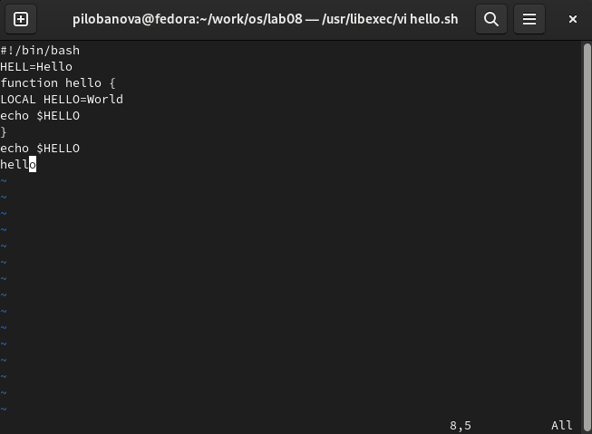

*Командный режим.*

## Режим вставки

Режим вставки предназначен для ввода содержания редактируемого файла.

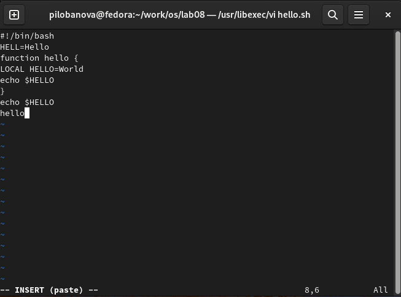

*Режим вставки.*

## Режим последней строки

Режим последней строки используется для записи изменений в файл и выхода из него.

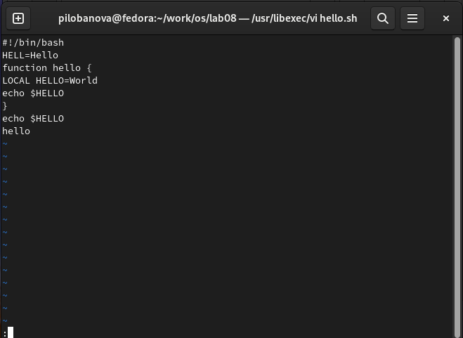

*Режим последней строки.*

# Контрольные вопросы

1. Дайте краткую характеристику режимам работы редактора vi.
2. Как выйти из редактора, не сохраняя произведённые изменения?
3. Назовите и дайте краткую характеристику командам позиционирования.
4. Что для редактора vi является словом?
5. Каким образом из любого места редактируемого файла перейти в начало (конец) файла?
6. Назовите и дайте краткую характеристику основным группам команд редактирования.
7. Необходимо заполнить строку символами $. Каковы ваши действия?
8. Как отменить некорректное действие, связанное с процессом редактирования?
9. Назовите и дайте характеристику основным группам команд режима последней строки.
10. Как определить, не перемещая курсора, позицию, в которой заканчивается строка?
11. Выполните анализ опций редактора vi (сколько их, как узнать их назначение и т.д.).
12. Как определить режим работы редактора vi?
13. Постройте граф взаимосвязи режимов работы редактора vi.

# Вывод

Я ознакомилась с операционной системой Linux, получила практические навыки работы с редактором vi.